# hw2 360

```r
library(ggplot2)
library(zoo)
library(tseries)
library(forecast)
library(ggcorrplot)
library(GGally)
library(ggplot2)
library(knitr)
library(rmarkdown)
```

First, I get the data and discard the last 4 rows since UGS has missing data in these rows. Then, I simplify columns names for easier usage.

```r
hw2_data <- read.csv("IE360_Spring22_HW2_data.csv")
f28 <- hw2_data[1:28,]
colnames(f28) <- c('Quarter','UGS','RNUV','NLPG','PU','PG','NUGV','NDGV','GNPA','GNPC','GNP')
```

Moreover, I need to prepare data, because some columns have spaces in their values. Also, I convert Quarter column to date.

```r
f28$Quarter=as.Date(as.yearqtr(f28$Quarter, format = "%Y_Q%q"))
f28$UGS=as.numeric(gsub(" ","",as.character(f28$UGS),fixed=TRUE))
f28$RNUV=as.numeric(gsub(" ","",as.character(f28$RNUV),fixed=TRUE))
f28$NLPG=as.numeric(gsub(" ","",as.character(f28$NLPG),fixed=TRUE))
f28$NUGV=as.numeric(gsub(" ","",as.character(f28$NUGV),fixed=TRUE))
f28$GNPA=as.numeric(gsub(" ","",as.character(f28$GNPA),fixed=TRUE))
f28$GNPC=as.numeric(gsub(" ","",as.character(f28$GNPC),fixed=TRUE))
f28$GNP=as.numeric(gsub(" ","",as.character(f28$GNP),fixed=TRUE))
```

I also define Trend and Quart for f28 data for further usage in models.

```r
f28$Trend=seq(0,27,by=1)
f28$Quart=seq(1,4,by=1)
```

Let’s define lag 1 and lag 4 as well.

```r
f28$lag1 <- NA
f28$lag4 <- NA
f28$lag1 <- dplyr::lag(f28$UGS, 1L)
f28$lag4 <- dplyr::lag(f28$UGS, 4L)
```

I plot the data

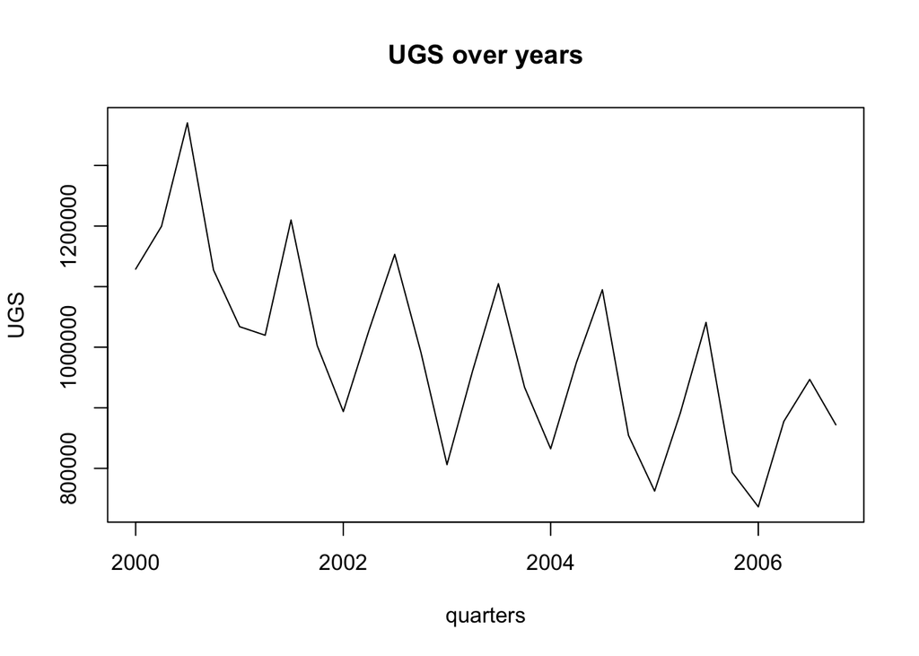

```r
plot(f28$Quarter,f28$UGS,type="l", xlab="quarters", ylab="UGS",main="UGS over years")
```

From plot above, it is seen that this time series has non-stationary mean and stationary variance.

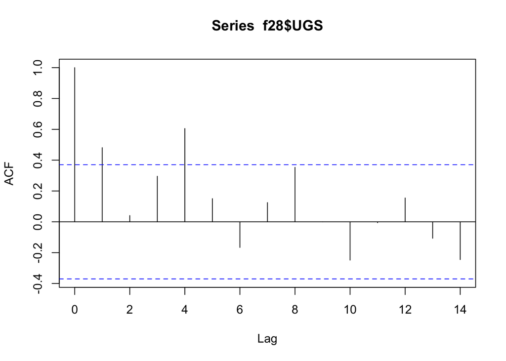

```r
acf(f28$UGS)
```

lag 1 has a significant value which indicates the trend, since each quarter is affected by the prior quarter. Also, lag 4 has a significant value which indicates seasonality.

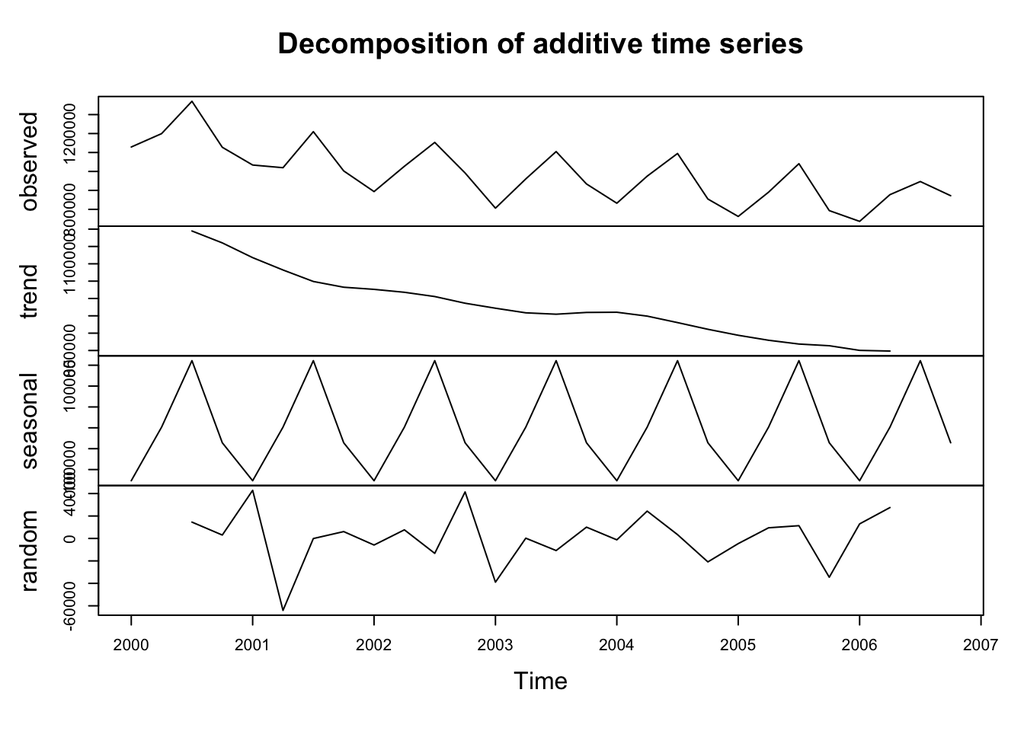

```r
UGS=f28$UGS
UGSts <- ts(UGS, freq=4, start=c(2000,1))
UGSdec<-decompose(UGSts,type="additive")
plot(UGSdec)
```

I decomposed data to have a better look.

```r
model1 <- lm(UGS~Trend, data=f28)
summary(model1)
```

```
##
## Call:
## lm(formula = UGS ~ Trend, data = f28)
##
## Residuals:
##     Min      1Q  Median      3Q     Max
## -199945  -73550  -21904   71224  237369
##
## Coefficients:
##             Estimate Std. Error t value Pr(>|t|)
## (Intercept)  1158117      41034  28.224  < 2e-16 ***
## Trend         -12660       2608  -4.854 4.95e-05 ***
## ---
## Signif. codes:  0 '***' 0.001 '**' 0.01 '*' 0.05 '.' 0.1 ' ' 1
##
## Residual standard error: 111500 on 26 degrees of freedom
## Multiple R-squared:  0.4754, Adjusted R-squared:  0.4552
## F-statistic: 23.56 on 1 and 26 DF,  p-value: 4.945e-05
```

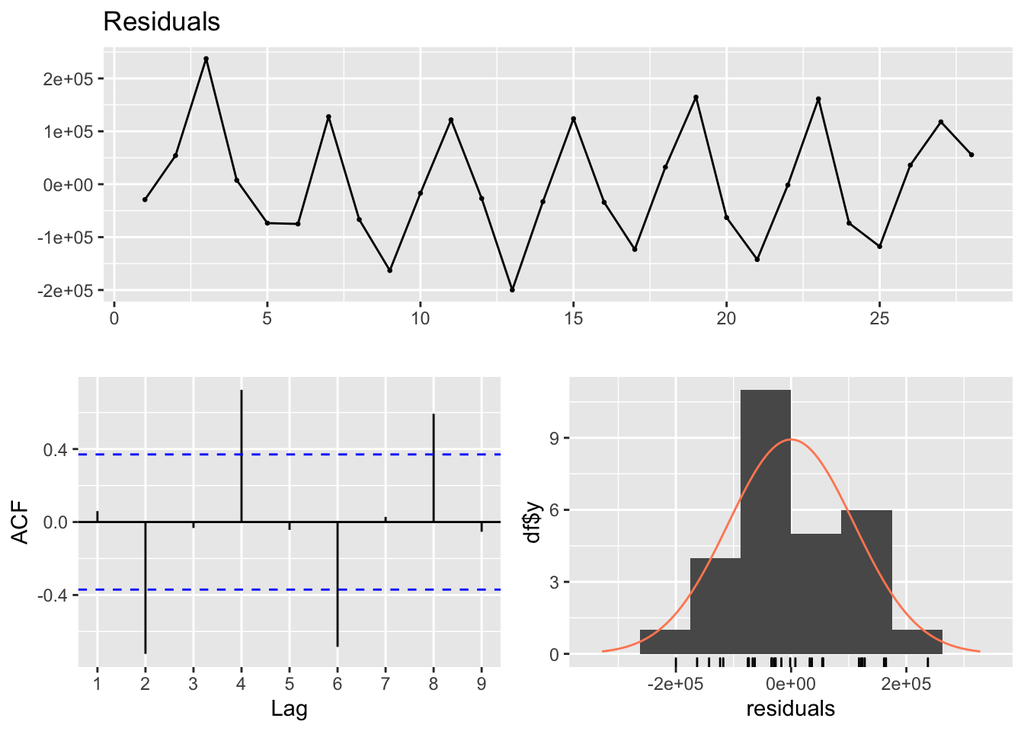

```
##
##  Breusch-Godfrey test for serial correlation of order up to 6
##
## data:  Residuals
## LM test = 19.942, df = 6, p-value = 0.002836
```

```r
checkresiduals(model1)
```

Using only trend.

```r
model2 <- lm(UGS~Trend+as.factor(Quart), data=f28)
summary(model2)
```

```
##
## Call:
## lm(formula = UGS ~ Trend + as.factor(Quart), data = f28)
##
## Residuals:
##    Min     1Q Median     3Q    Max
## -81167 -31283  -3458  28640  94502
##
## Coefficients:
##                   Estimate Std. Error t value Pr(>|t|)
## (Intercept)        1046875      22947  45.621  < 2e-16 ***
## Trend               -13497       1147 -11.764 3.28e-11 ***
## as.factor(Quart)2   121532      25987   4.677 0.000104 ***
## as.factor(Quart)3   273618      26063  10.498 3.03e-10 ***
## as.factor(Quart)4    95049      26189   3.629 0.001405 **
## ---
## Signif. codes:  0 '***' 0.001 '**' 0.01 '*' 0.05 '.' 0.1 ' ' 1
##
## Residual standard error: 48570 on 23 degrees of freedom
## Multiple R-squared:  0.9119, Adjusted R-squared:  0.8966
## F-statistic: 59.53 on 4 and 23 DF,  p-value: 8.446e-12
```

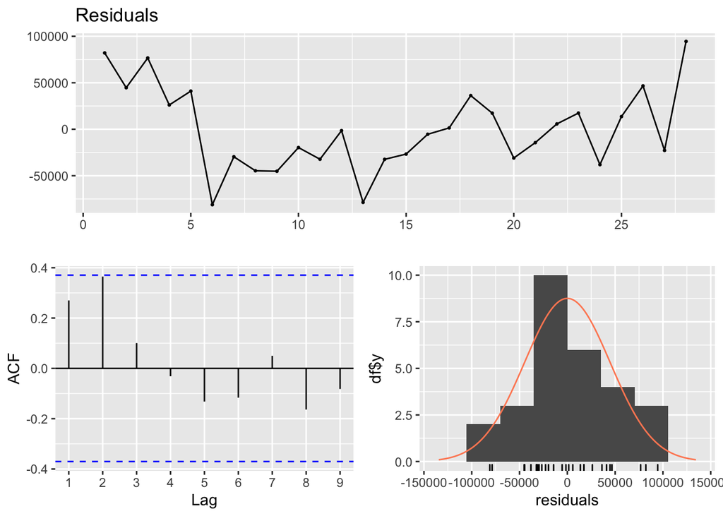

```
##
##  Breusch-Godfrey test for serial correlation of order up to 8
##
## data:  Residuals
## LM test = 11.462, df = 8, p-value = 0.1769
```

```r
checkresiduals(model2)
```

Seasonality added.

```r
model3 <- lm(UGS ~ Trend+as.factor(Quart)+lag1, data=f28)
summary(model3)
```

```
##
## Call:
## lm(formula = UGS ~ Trend + as.factor(Quart) + lag1, data = f28)
##
## Residuals:
##    Min     1Q Median     3Q    Max
## -87046 -18851   2692  19111  90358
##
## Coefficients:
##                     Estimate Std. Error t value Pr(>|t|)
## (Intercept)        6.384e+05  2.465e+05   2.590   0.0171 *
## Trend             -8.004e+03  3.241e+03  -2.470   0.0222 *
## as.factor(Quart)2  1.627e+05  2.990e+04   5.441 2.13e-05 ***
## as.factor(Quart)3  2.732e+05  2.612e+04  10.457 8.80e-10 ***
## as.factor(Quart)4  4.278e+04  4.830e+04   0.886   0.3858
## lag1               3.344e-01  2.132e-01   1.569   0.1317
## ---
## Signif. codes:  0 '***' 0.001 '**' 0.01 '*' 0.05 '.' 0.1 ' ' 1
##
## Residual standard error: 44080 on 21 degrees of freedom
##   (1 observation deleted due to missingness)
## Multiple R-squared:  0.9314, Adjusted R-squared:  0.9151
## F-statistic: 57.06 on 5 and 21 DF,  p-value: 1.651e-11
```

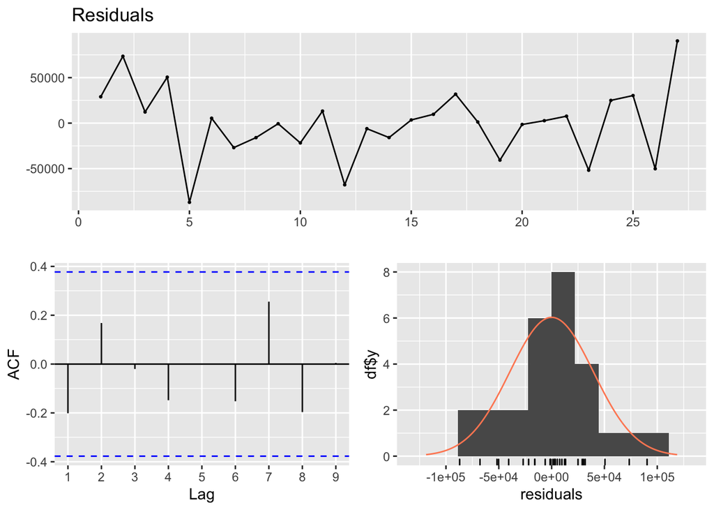

```
##
##  Breusch-Godfrey test for serial correlation of order up to 9
##
## data:  Residuals
## LM test = 10.208, df = 9, p-value = 0.3339
```

```r
checkresiduals(model3)
```

lag 1 added, performed better

```r
model4 <- lm(UGS ~ Trend+as.factor(Quart)+lag4, data=f28)
summary(model4)
```

```
##
## Call:
## lm(formula = UGS ~ Trend + as.factor(Quart) + lag4, data = f28)
##
## Residuals:
##    Min     1Q Median     3Q    Max
## -55595 -18251   -287  17100  78068
##
## Coefficients:
##                     Estimate Std. Error t value Pr(>|t|)
## (Intercept)        9.048e+05  2.255e+05   4.012 0.000818 ***
## Trend             -9.436e+03  3.243e+03  -2.909 0.009353 **
## as.factor(Quart)2  1.156e+05  3.248e+04   3.561 0.002235 **
## as.factor(Quart)3  2.465e+05  6.091e+04   4.048 0.000755 ***
## as.factor(Quart)4  8.896e+04  2.848e+04   3.124 0.005862 **
## lag4               7.867e-02  2.001e-01   0.393 0.698744
## ---
## Signif. codes:  0 '***' 0.001 '**' 0.01 '*' 0.05 '.' 0.1 ' ' 1
##
## Residual standard error: 38700 on 18 degrees of freedom
##   (4 observations deleted due to missingness)
## Multiple R-squared:  0.9235, Adjusted R-squared:  0.9022
## F-statistic: 43.45 on 5 and 18 DF,  p-value: 1.994e-09
```

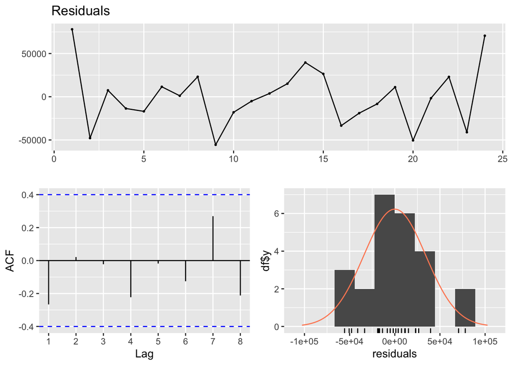

```
##
##  Breusch-Godfrey test for serial correlation of order up to 9
##
## data:  Residuals
## LM test = 13.278, df = 9, p-value = 0.1504
```

```r
checkresiduals(model4)
```

lag 4 was not as good as lag 1, so I will continue with lag 1 and try independent variables.

```r
model5 <- lm(UGS ~ Trend+as.factor(Quart)+lag1+NUGV, data=f28)
summary(model5)
```

```
##
## Call:
## lm(formula = UGS ~ Trend + as.factor(Quart) + lag1 + NUGV, data = f28)
##
## Residuals:
##    Min     1Q Median     3Q    Max
## -93294 -20110   5309  17702  79269
##
## Coefficients:
##                     Estimate Std. Error t value Pr(>|t|)
## (Intercept)        2.703e+05  5.765e+05   0.469   0.6443
## Trend             -1.133e+04  5.722e+03  -1.979   0.0617 .
## as.factor(Quart)2  1.607e+05  3.040e+04   5.285 3.58e-05 ***
## as.factor(Quart)3  2.734e+05  2.644e+04  10.339 1.80e-09 ***
## as.factor(Quart)4  4.498e+04  4.898e+04   0.918   0.3694
## lag1               3.080e-01  2.189e-01   1.407   0.1749
## NUGV               8.440e-02  1.192e-01   0.708   0.4869
## ---
## Signif. codes:  0 '***' 0.001 '**' 0.01 '*' 0.05 '.' 0.1 ' ' 1
##
## Residual standard error: 44610 on 20 degrees of freedom
##   (1 observation deleted due to missingness)
## Multiple R-squared:  0.9331, Adjusted R-squared:  0.9131
## F-statistic: 46.51 on 6 and 20 DF,  p-value: 1.042e-10
```

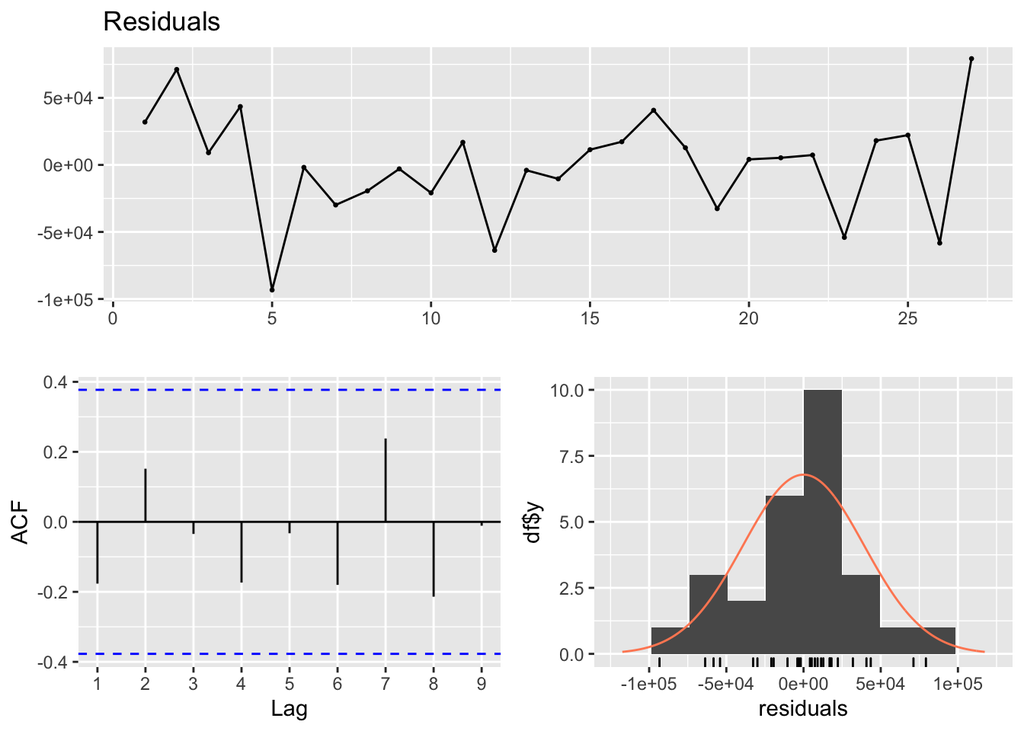

```
##
##  Breusch-Godfrey test for serial correlation of order up to 10
##
## data:  Residuals
## LM test = 12.601, df = 10, p-value = 0.2469
```

```r
checkresiduals(model5)
```

```r
model6 <- lm(UGS ~ Trend+as.factor(Quart)+lag1+NUGV+NLPG, data=f28)
summary(model6)
```

```
##
## Call:
## lm(formula = UGS ~ Trend + as.factor(Quart) + lag1 + NUGV + NLPG,
##     data = f28)
##
## Residuals:
##    Min     1Q Median     3Q    Max
## -85388 -16863   1878  16838  75516
##
## Coefficients:
##                     Estimate Std. Error t value Pr(>|t|)
## (Intercept)        4.561e+05  5.310e+05   0.859 0.401108
## Trend             -2.626e+04  8.397e+03  -3.128 0.005540 **
## as.factor(Quart)2  1.319e+05  3.043e+04   4.336 0.000356 ***
## as.factor(Quart)3  2.897e+05  2.512e+04  11.533 5.05e-10 ***
## as.factor(Quart)4  1.107e+05  5.317e+04   2.082 0.051106 .
## lag1              -4.500e-02  2.528e-01  -0.178 0.860632
## NUGV               8.373e-02  1.084e-01   0.772 0.449576
## NLPG               2.911e-01  1.283e-01   2.268 0.035178 *
## ---
## Signif. codes:  0 '***' 0.001 '**' 0.01 '*' 0.05 '.' 0.1 ' ' 1
##
## Residual standard error: 40600 on 19 degrees of freedom
##   (1 observation deleted due to missingness)
## Multiple R-squared:  0.9474, Adjusted R-squared:  0.928
## F-statistic: 48.86 on 7 and 19 DF,  p-value: 8.003e-11
```

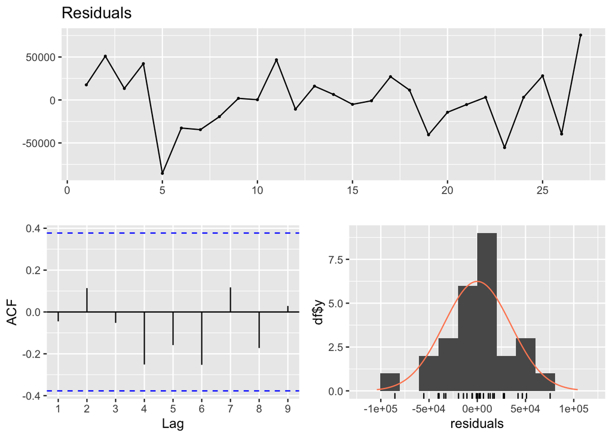

```
##
##  Breusch-Godfrey test for serial correlation of order up to 11
##
## data:  Residuals
## LM test = 13.407, df = 11, p-value = 0.2676
```

```r
checkresiduals(model6)
```

NLPG also increased adjusted r squared

```r
model7 <- lm(UGS ~ Trend+as.factor(Quart)+lag1+NUGV+NLPG+PG, data=f28)
summary(model7)
```

```
##
## Call:
## lm(formula = UGS ~ Trend + as.factor(Quart) + lag1 + NUGV + NLPG +
##     PG, data = f28)
##
## Residuals:
##    Min     1Q Median     3Q    Max
## -73639 -20076   2575  15265  67440
##
## Coefficients:
##                     Estimate Std. Error t value Pr(>|t|)
## (Intercept)        5.355e+05  4.988e+05   1.074 0.297207
## Trend             -2.295e+04  8.047e+03  -2.852 0.010587 *
## as.factor(Quart)2  1.373e+05  2.862e+04   4.798 0.000144 ***
## as.factor(Quart)3  3.001e+05  2.413e+04  12.436 2.83e-10 ***
## as.factor(Quart)4  1.136e+05  4.979e+04   2.281 0.034931 *
## lag1              -6.167e-02  2.368e-01  -0.260 0.797501
## NUGV               1.185e-01  1.031e-01   1.149 0.265487
## NLPG               2.402e-01  1.230e-01   1.953 0.066561 .
## PG                -5.884e+02  3.066e+02  -1.919 0.070939 .
## ---
## Signif. codes:  0 '***' 0.001 '**' 0.01 '*' 0.05 '.' 0.1 ' ' 1
##
## Residual standard error: 38010 on 18 degrees of freedom
##   (1 observation deleted due to missingness)
## Multiple R-squared:  0.9563, Adjusted R-squared:  0.9369
## F-statistic: 49.25 on 8 and 18 DF,  p-value: 1.131e-10
```

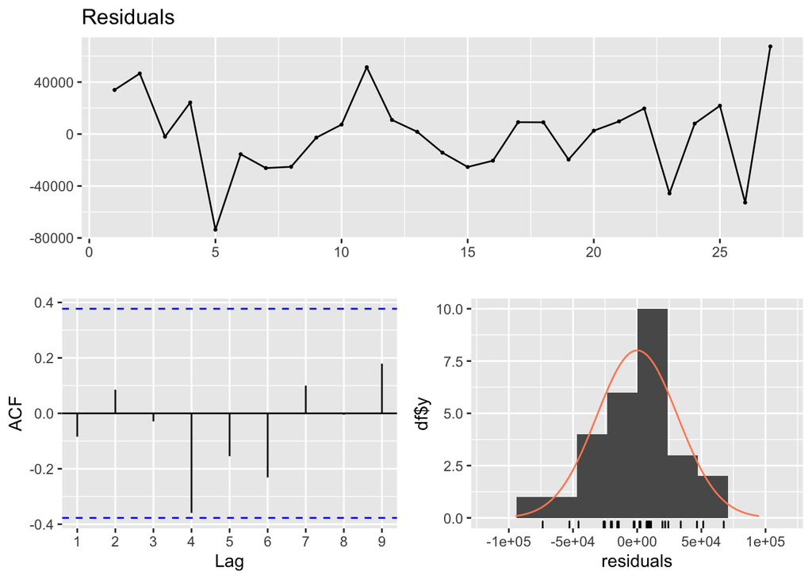

```
##
##  Breusch-Godfrey test for serial correlation of order up to 12
##
## data:  Residuals
## LM test = 22.28, df = 12, p-value = 0.0345
```

```r
checkresiduals(model7)
```

PG added

```r
model8 <- lm(UGS ~ Trend+as.factor(Quart)+lag1+NUGV+NLPG+PG+NDGV, data=f28)
summary(model8)
```

```
##
## Call:
## lm(formula = UGS ~ Trend + as.factor(Quart) + lag1 + NUGV + NLPG +
##     PG + NDGV, data = f28)
##
## Residuals:
##    Min     1Q Median     3Q    Max
## -49526 -15476   1921  14636  38171
##
## Coefficients:
##                     Estimate Std. Error t value Pr(>|t|)
## (Intercept)        3.786e+06  8.146e+05   4.648 0.000230 ***
## Trend              8.159e+03  9.025e+03   0.904 0.378562
## as.factor(Quart)2  8.084e+04  2.381e+04   3.395 0.003443 **
## as.factor(Quart)3  3.043e+05  1.697e+04  17.937 1.76e-12 ***
## as.factor(Quart)4  2.005e+05  4.010e+04   5.000 0.000110 ***
## lag1              -4.746e-01  1.907e-01  -2.489 0.023474 *
## NUGV              -1.194e+00  3.057e-01  -3.907 0.001135 **
## NLPG              -2.524e-01  1.410e-01  -1.790 0.091265 .
## PG                -9.503e+02  2.302e+02  -4.128 0.000704 ***
## NDGV               1.446e+04  3.272e+03   4.420 0.000375 ***
## ---
## Signif. codes:  0 '***' 0.001 '**' 0.01 '*' 0.05 '.' 0.1 ' ' 1
##
## Residual standard error: 26680 on 17 degrees of freedom
##   (1 observation deleted due to missingness)
## Multiple R-squared:  0.9797, Adjusted R-squared:  0.9689
## F-statistic: 91.03 on 9 and 17 DF,  p-value: 1.346e-12
```

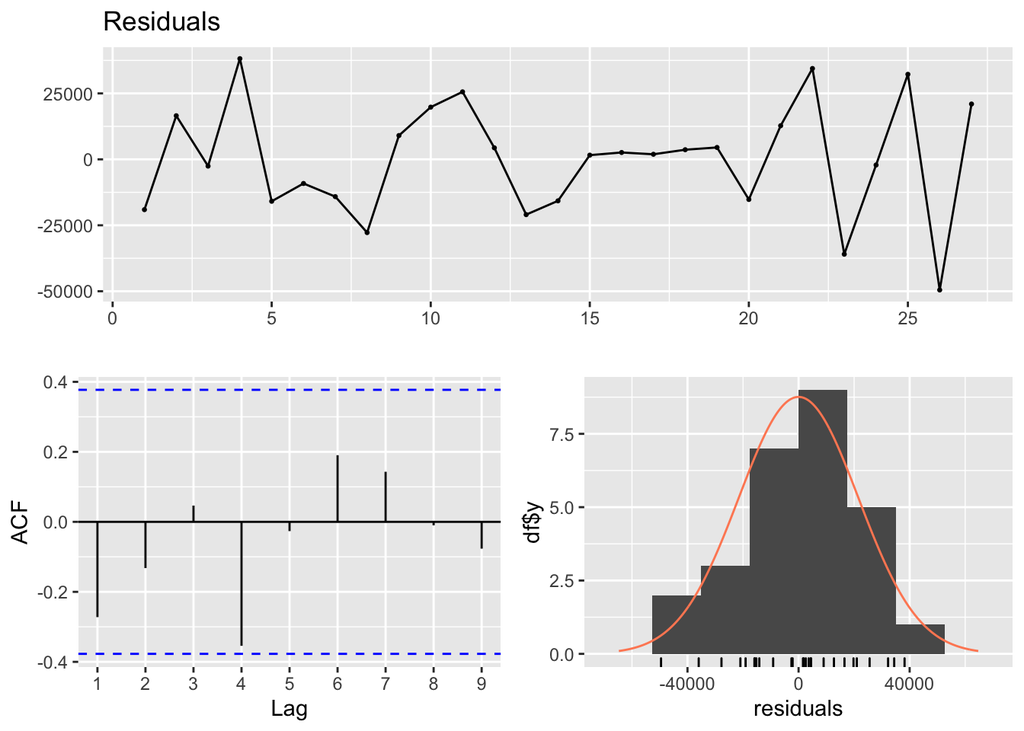

```
##
##  Breusch-Godfrey test for serial correlation of order up to 13
##
## data:  Residuals
## LM test = 23.531, df = 13, p-value = 0.03573
```

```r
checkresiduals(model8)
```

NDGV added, our model is continuing to improve

```r
model9 <- lm(UGS ~ Trend+as.factor(Quart)+lag1+NUGV+NLPG+PG+NDGV+PU, data=f28)
summary(model9)
```

```
##
## Call:
## lm(formula = UGS ~ Trend + as.factor(Quart) + lag1 + NUGV + NLPG +
##     PG + NDGV + PU, data = f28)
##
## Residuals:
##    Min     1Q Median     3Q    Max
## -48735 -14093   -556  15118  37102
##
## Coefficients:
##                     Estimate Std. Error t value Pr(>|t|)
## (Intercept)        3.573e+06  9.229e+05   3.871 0.001354 **
## Trend              3.633e+03  1.250e+04   0.291 0.775091
## as.factor(Quart)2  8.338e+04  2.478e+04   3.365 0.003945 **
## as.factor(Quart)3  3.066e+05  1.786e+04  17.171  9.9e-12 ***
## as.factor(Quart)4  2.029e+05  4.121e+04   4.923 0.000153 ***
## lag1              -4.954e-01  1.986e-01  -2.494 0.023962 *
## NUGV              -1.093e+00  3.655e-01  -2.989 0.008676 **
## NLPG              -2.018e-01  1.722e-01  -1.172 0.258395
## PG                -2.499e+02  1.327e+03  -0.188 0.853030
## NDGV               1.343e+04  3.857e+03   3.482 0.003078 **
## PU                -5.184e+02  9.670e+02  -0.536 0.599249
## ---
## Signif. codes:  0 '***' 0.001 '**' 0.01 '*' 0.05 '.' 0.1 ' ' 1
##
## Residual standard error: 27250 on 16 degrees of freedom
##   (1 observation deleted due to missingness)
## Multiple R-squared:   0.98,  Adjusted R-squared:  0.9675
## F-statistic: 78.52 on 10 and 16 DF,  p-value: 1.165e-11
```

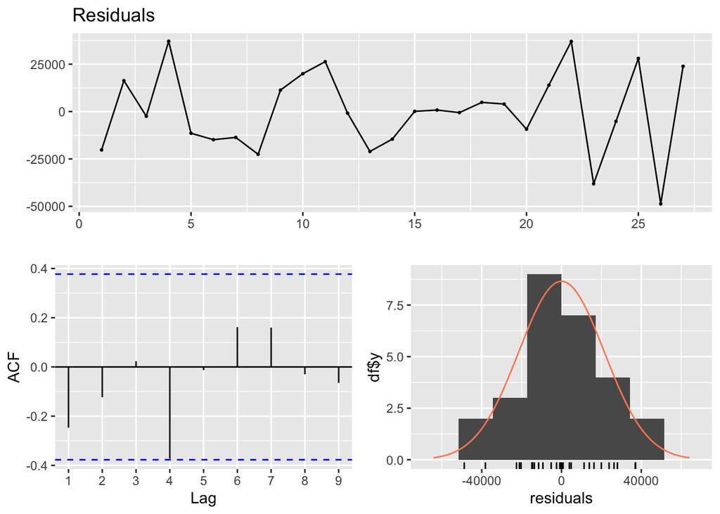

```
##
##  Breusch-Godfrey test for serial correlation of order up to 14
##
## data:  Residuals
## LM test = 26.566, df = 14, p-value = 0.02191
```

```r
checkresiduals(model9)
```

PU sligthly decreased adjusted r squared

```r
model10 <- lm(UGS ~ Trend+as.factor(Quart)+lag4+NUGV+NLPG+PG+NDGV+PU, data=f28)
summary(model10)
```

```
##
## Call:
## lm(formula = UGS ~ Trend + as.factor(Quart) + lag4 + NUGV + NLPG +
##     PG + NDGV + PU, data = f28)
##
## Residuals:
##    Min     1Q Median     3Q    Max
## -61914  -9623    -80  18546  36573
##
## Coefficients:
##                     Estimate Std. Error t value Pr(>|t|)
## (Intercept)        3.188e+06  1.463e+06   2.178  0.04838 *
## Trend              1.327e+04  1.951e+04   0.680  0.50839
## as.factor(Quart)2  1.317e+05  3.635e+04   3.623  0.00309 **
## as.factor(Quart)3  2.905e+05  7.078e+04   4.104  0.00124 **
## as.factor(Quart)4  1.168e+05  2.978e+04   3.922  0.00175 **
## lag4              -2.401e-02  2.385e-01  -0.101  0.92137
## NUGV              -1.113e+00  6.692e-01  -1.663  0.12025
## NLPG              -2.806e-01  2.466e-01  -1.138  0.27571
## PG                -5.538e+02  1.642e+03  -0.337  0.74135
## NDGV               1.336e+04  7.196e+03   1.857  0.08618 .
## PU                -2.338e+02  1.198e+03  -0.195  0.84833
## ---
## Signif. codes:  0 '***' 0.001 '**' 0.01 '*' 0.05 '.' 0.1 ' ' 1
##
## Residual standard error: 33720 on 13 degrees of freedom
##   (4 observations deleted due to missingness)
## Multiple R-squared:  0.958,  Adjusted R-squared:  0.9258
## F-statistic: 29.69 on 10 and 13 DF,  p-value: 2.551e-07
```

just wanted to check lag4 but it is not good

```r
hw2_data <- read.csv("IE360_Spring22_HW2_data.csv")
colnames(hw2_data) <- c('Quarter','UGS','RNUV','NLPG','PU','PG','NUGV','NDGV','GNPA','GNPC','GNP')
hw2_data$Quarter=as.Date(as.yearqtr(hw2_data$Quarter, format = "%Y_Q%q"))
hw2_data$UGS=as.numeric(gsub(" ","",as.character(hw2_data$UGS),fixed=TRUE))
hw2_data$RNUV=as.numeric(gsub(" ","",as.character(hw2_data$RNUV),fixed=TRUE))
hw2_data$NLPG=as.numeric(gsub(" ","",as.character(hw2_data$NLPG),fixed=TRUE))
hw2_data$NUGV=as.numeric(gsub(" ","",as.character(hw2_data$NUGV),fixed=TRUE))
hw2_data$GNPA=as.numeric(gsub(" ","",as.character(hw2_data$GNPA),fixed=TRUE))
hw2_data$GNPC=as.numeric(gsub(" ","",as.character(hw2_data$GNPC),fixed=TRUE))
hw2_data$GNP=as.numeric(gsub(" ","",as.character(hw2_data$GNP),fixed=TRUE))
hw2_data$Trend=seq(0,31,by=1)
hw2_data$Quart=seq(1,4,by=1)
```

Let’s get the data again and fill the empty places by our predictions.

```r
hw2_data$lag1 <- NA
hw2_data$lag1 <- dplyr::lag(hw2_data$UGS, 1L)

hw2_data[29,2]=predict(model9,newdata=hw2_data[29,])
hw2_data$lag1[30]=hw2_data[29,2]
hw2_data[30,2]=predict(model9,newdata=hw2_data[30,])
hw2_data$lag1[31]=hw2_data[30,2]
hw2_data[31,2]=predict(model9,newdata=hw2_data[31,])
hw2_data$lag1[32]=hw2_data[31,2]
hw2_data[32,2]=predict(model9,newdata=hw2_data[32,])
hw2_data
```

```
##       Quarter       UGS   RNUV    NLPG     PU     PG    NUGV     NDGV    GNPA
## 1  2000-01-01 1128971.0 0.0146  940000 469.03 355.69 4647500 281.9853 1040173
## 2  2000-04-01 1199569.0 0.0205  941000 459.42 344.58 4742876 284.0813 1760460
## 3  2000-07-01 1370167.0 0.0207  943500 439.98 327.21 4840931 286.7169 6974808
## 4  2000-10-01 1127548.0 0.0163  948000 402.08 300.67 4919685 288.3137 3267125
## 5  2001-01-01 1033918.0 0.0071  950000 411.58 305.75 4954754 287.6237 1004528
## 6  2001-04-01 1019754.0 0.0051  955000 520.39 374.78 4980204 287.8814 1449357
## 7  2001-07-01 1209916.0 0.0041  967500 530.37 398.71 5000446 287.5452 5890424
## 8  2001-10-01 1002789.0 0.0048  990000 496.35 370.70 5024693 286.9786 1940854
## 9  2002-01-01  893722.0 0.0012 1000000 479.52 352.72 5030810 286.3783  832953
## 10 2002-04-01 1027252.0 0.0032 1001000 506.36 373.44 5046960 286.0471 1419764
## 11 2002-07-01 1153265.0 0.0034 1003500 533.66 404.49 5064066 285.8790 6340745
## 12 2002-10-01  991981.0 0.0044 1008000 506.90 390.75 5086547 286.1087 2258470
## 13 2003-01-01  806257.0 0.0019 1010000 537.50 425.00 5096278 285.8286  841604
## 14 2003-04-01  960556.0 0.0056 1048000 502.06 382.47 5125065 286.2459 1519490
```

[output cut: 51 more lines]

This is my complete data, my predictions are 2007-01-01 674530.3  
2007-04-01 853229.1 2007-07-01 981380.4  
2007-10-01 805738.9